# **Homework 5**

Kevin Ha

October 16, 2021

### **Problem 7.71**

##### Problem 7.71a

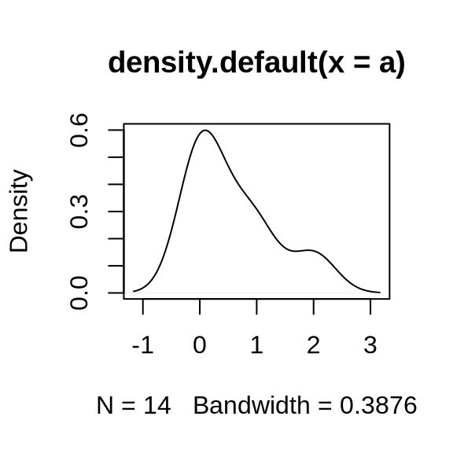

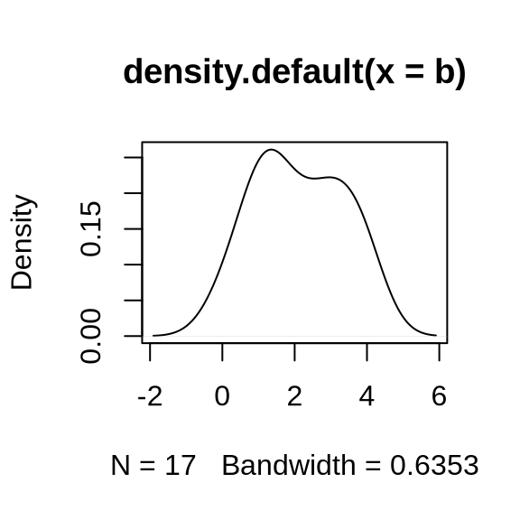

In examining the density of the values, there isn’t a clear normal distribution shown.

**However since there is no presence of outliers or indication of strong skewness and $15 < n_1 + n_2 < 40$, where $n_1 =$ sample size of neutral group and $n_2 =$ sample size of sad group, the t procedures can still be used.**

##### Problem 7.71b

```
##         Sample Size       Mean  Std. Dev.
## Neutral  14.0000000  0.5714286  0.7300459
## Sad      17.0000000  2.1176471  1.2441037
```

##### Problem 7.71c

$H_0 : \mu_{Neutral} = \mu_{Sad}$

$H_a: \mu_{Neutral} < \mu_{Sad}$

##### Problem 7.71d

T-statistic formula:

$t = \frac{\overline{X}_A - \overline{X}_B}{\sqrt{\frac{S^2_A}{n_A} + \frac{S^2_A}{n_B}}} = \frac{0.57 - 2.12}{\sqrt{\frac{0.73^2}{14} + \frac{1.24^2}{17}}} = -4.3030975$

P-value is calculated using the t-value found above and $df = 13$ since $n_A - 1 < n_B - 1$

```r
pt(-4.3030975, 13)
```

```
## [1] 0.0004291661
```

**The p-value is extremely low enough to indicate the conclusion that the null hypothesis, $H_0$ should be rejected and a person’s average spending is higher when they are sad.**

##### Problem 7.71e

Confidence interval formula:

$(\bar{x_1} - \bar{x_2}) \pm t^*\sqrt{\frac{s^2_A}{n_A} + \frac{s^2_B}{n_B}}$

First calculate critical T-value, using $df = 13$

```r
t_value <- qt(0.025, 13)
t_value
```

```
## [1] -2.160369
```

$\sqrt{\frac{s^2_A}{n_A} + \frac{s^2_B}{n_B}} = 0.3593269$

The interval when $df = 13$:

**-2.3224971 to -0.7699399**

### **Problem 7.89**

##### Problem 7.89a

$H_0: \mu_{bf} = \mu_{formula}$

$H_a: \mu_{bf} > \mu_{formula}$

```r
1 - pt(1.6537344, 18)
```

```
## [1] 0.05775748
```

**The p-value when using $\alpha = 0.05$ indicates that the data does not provide substantial evidence to reject the null hypothesis, $H_0$**

##### Problem 7.89b

Confidence interval formula:

$(\bar{x_1} - \bar{x_2}) \pm t^*\sqrt{\frac{s^2_A}{n_A} + \frac{s^2_B}{n_B}}$

First calculate critical T-value, using $df = 18$

```r
t_value <- qt(0.05, 18)
t_value
```

```
## [1] -1.734064
```

##### Problem 7.89c

**The assumptions are that we have two independent SRS from two distinct populations that are both normally distributed.**

### **Problem 7.102**

##### Problem 7.102a

$F = \frac{\sigma_{larger}}{\sigma_{smaller}} = \frac{s^2_1} {s^2_2} = \frac{9.1}{3.5} = 2.6$

##### Problem 7.102b

The appropriate value is given by the $F(15, 10)$ distribution at the 0.05 significance level.

$F(15, 10) = 2.49$

##### Problem 7.102c

**The results are significant at the 5% level since the calculated F test statistic is greater than the F-value found in the 0.05 significance level of the $F(15, 10)$ distribution.**

**The null hypothesis can also be rejected because of this.**

### **Problem 7.122**

##### Problem 7.122a

```
##         Sample Size      Mean  Variance
## Group 1   10.000000 49.692000  5.372640
## Group 2   10.000000 50.545000  3.703161
```

```r
result <- t.test(group1, group2, var.equal=FALSE)
result$parameter
```

```
##       df
## 17.41087
```

T-statistic formula:

$t = \frac{\overline{X}_A - \overline{X}_B}{\sqrt{\frac{S^2_A}{n_A} + \frac{S^2_A}{n_B}}} = -0.8953783$

P-value (two-tailed test) is calculated using the t-value found above and $df = 17$

```r
2 * pt(-0.8953783, 17)
```

```
## [1] 0.383088
```

##### Problem 7.122b

```
## [1] "Mean of the differences: -0.853"
```

```
## [1] "Variance of the differences: 1.611"
```

```
## [1] "Standard deviation of the differences: 1.269"
```

Paired T-statistic formula:

$t = \frac{\overline{X}_{diff}}{\sqrt{\frac{S^2_{diff}}{n_{total}}}} = -2.1254263$

P-value (two-tailed test) is calculated using the t-value found above and $df = 10 - 1 = 9$

```r
2 * pt(-2.1254263, 9)
```

```
## [1] 0.06248424
```

##### Problem 7.122c

**The differences in the degrees of freedom were the result of using an unpaired and paired test and if $\alpha = 0.05$ both p-values are not statistically significant and the differences are result of using a two sample vs one sample t test.**

### **Problem 8.71**

##### Problem 8.71a

Proportion for females juveniles:

$\hat{p}_{f} = \frac{48}{60} = 0.8$

Standard error for females juveniles:

$SE \hat{p}_{f} = \sqrt{\frac{p(1-p)}{n}} = \sqrt{\frac{0.8(0.2)}{60}} = 0.0516398$

Proportion for male juveniles:

$\hat{p}_{m} = \frac{52}{132} = 0.3939394$

Standard error for male juveniles:

$SE \hat{p}_{m} = \sqrt{\frac{p(1-p)}{n}} = \sqrt{\frac{0.3939(1-0.3939)}{132}} = 0.0425283$

##### Problem 8.71b

Difference in population proportions:

$D = \hat{p}_{f} - \hat{p}_{m} = 0.4061$

Standard error of D:

$SE_{D} = \sqrt{\frac{\hat{p}_f(1-\hat{p}_f)}{n_f} + \frac{\hat{p}_m(1-\hat{p}_m)}{n_m}} = 0.0668979$

Margin of error for 90% confidence interval:

$MoE = z* \sqrt{SE_{D}} = 0.110047$

90% confidence interval:

$0.4061 \pm 0.110047$

$0.296053$ to $0.516147$

**Summary: With 90% confidence, the difference in proportion of female references to male references lies in between $(0.296053, 0.516147)$**

##### Problem 8.71c

First, find the pooled sample proportion, $p$:

$\hat{p} = \frac{48+52}{60+132} = 0.5208333$

Next, calculate the pooled standard error:

$SED_p = \sqrt{\hat{p} (1-\hat{p}) \frac{1}{n_1} + \frac{1}{n_2}} = 0.0777823$

Z statistic formula:

$z = \frac{\hat{p}_f - \hat{p}_m}{SED_p} = 5.2209822$

$P \approx 0$

```r
2*(1-pnorm(5.2209822))
```

```
## [1] 1.779766e-07
```

**The near 0 p-value provides strong evidence to indicate that the null hypothesis of the two proportions being equal should be rejected.**